# Construct Two Parameter Hierarchical P/NBD Model for Long Timeframe Synthetic Data

Author

Mick Cooney mickcooney@gmail.com

Published

February 16, 2024

# 1 Load and Construct Datasets

## 1.1 Load Long-Timeframe Synthetic Transaction Data

```r
customer_cohortdata_tbl <- read_rds("data/longsynth_customer_cohort_data_tbl.rds")
customer_cohortdata_tbl |> glimpse()
```

```
Rows: 5,000
Columns: 5
$ customer_id     <chr> "LFC201001_0001", "LFC201001_0002", "LFC201001_0003", …
$ cohort_qtr      <chr> "2010 Q1", "2010 Q1", "2010 Q1", "2010 Q1", "2010 Q1",…
$ cohort_ym       <chr> "2010 01", "2010 01", "2010 01", "2010 01", "2010 01",…
$ first_tnx_date  <dttm> 2010-01-01 04:21:16, 2010-01-03 11:37:28, 2010-01-03 …
$ total_tnx_count <int> 3, 2, 9, 1, 4, 5, 80, 2, 3, 4, 16, 11, 22, 1, 2, 8, 4,…
```

```r
customer_transactions_tbl <- read_rds("data/longsynth_transaction_data_tbl.rds")
customer_transactions_tbl |> glimpse()
```

```
Rows: 43,153
Columns: 8
$ customer_id   <fct> LFC201001_0001, LFC201001_0003, LFC201001_0002, LFC20100…
$ tnx_timestamp <dttm> 2010-01-01 04:21:16, 2010-01-03 09:17:44, 2010-01-03 11…
$ tnx_dow       <fct> Fri, Sun, Sun, Tue, Wed, Wed, Fri, Sat, Sun, Mon, Tue, T…
$ tnx_month     <fct> Jan, Jan, Jan, Jan, Jan, Jan, Jan, Jan, Jan, Jan, Jan, J…
$ tnx_week      <chr> "00", "00", "00", "01", "01", "01", "01", "01", "01", "0…
$ invoice_id    <chr> "T20100101-0001", "T20100103-0001", "T20100103-0002", "T…
$ tnx_amount    <dbl> 82.97, 174.89, 126.14, 121.05, 99.23, 238.19, 54.69, 116…
$ orig_id       <chr> "LFC201001_0001", "LFC201001_0003", "LFC201001_0002", "L…
```

```r
customer_subset_id <- read_rds("data/longsynth_customer_subset_ids.rds")
customer_subset_id |> glimpse()
```

```
 Factor w/ 5000 levels "LFC201001_0001",..: 2 8 10 14 16 17 27 30 33 35 ...
```

We re-produce the visualisation of the transaction times we used in previous workbooks.

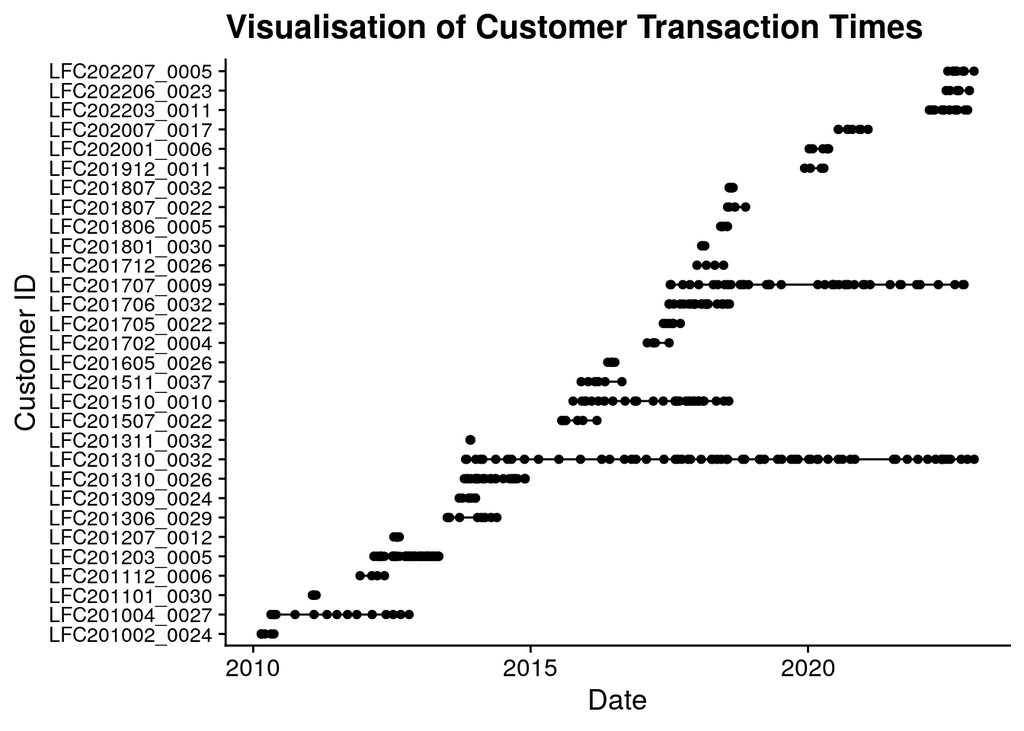

```r
plot_tbl <- customer_transactions_tbl |>
  group_nest(customer_id, .key = "cust_data") |>
  filter(map_int(cust_data, nrow) > 3) |>
  slice_sample(n = 30) |>
  unnest(cust_data)

ggplot(plot_tbl, aes(x = tnx_timestamp, y = customer_id)) +
  geom_line() +
  geom_point() +
  labs(
      x = "Date",
      y = "Customer ID",
      title = "Visualisation of Customer Transaction Times"
    ) +
  theme(axis.text.y = element_text(size = 10))
```

## 1.2 Load Derived Data

```r
obs_fitdata_tbl   <- read_rds("data/longsynth_obs_fitdata_tbl.rds")
obs_validdata_tbl <- read_rds("data/longsynth_obs_validdata_tbl.rds")

customer_fit_stats_tbl <- obs_fitdata_tbl |>
  rename(x = tnx_count)
```

## 1.3 Load Subset Data

We also want to construct our data subsets for the purposes of speeding up our valuations.

```r
customer_fit_subset_tbl <- obs_fitdata_tbl |>
  filter(customer_id %in% customer_subset_id)

customer_fit_subset_tbl |> glimpse()
```

```
Rows: 1,000
Columns: 6
$ customer_id    <fct> LFC201001_0003, LFC201001_0008, LFC201001_0010, LFC2010…
$ first_tnx_date <dttm> 2010-01-03 09:17:44, 2010-01-10 12:32:30, 2010-01-12 0…
$ last_tnx_date  <dttm> 2010-07-17 16:36:08, 2010-01-19 09:01:12, 2010-03-31 1…
$ tnx_count      <dbl> 8, 1, 3, 7, 1, 0, 1, 0, 2, 3, 19, 3, 2, 16, 1, 0, 0, 20…
$ t_x            <dbl> 27.9006351, 1.2647520, 11.1995948, 5.2948422, 0.6744781…
$ T_cal          <dbl> 625.8018, 624.7825, 624.5516, 623.8087, 623.7467, 623.5…
```

```r
customer_valid_subset_tbl <- obs_validdata_tbl |>
  filter(customer_id %in% customer_subset_id)

customer_valid_subset_tbl |> glimpse()
```

```
Rows: 1,000
Columns: 3
$ customer_id       <fct> LFC201001_0003, LFC201001_0008, LFC201001_0010, LFC2…
$ tnx_count         <dbl> 0, 0, 0, 0, 0, 0, 0, 0, 0, 0, 0, 0, 0, 0, 0, 0, 0, 0…
$ tnx_last_interval <dbl> NA, NA, NA, NA, NA, NA, NA, NA, NA, NA, NA, NA, NA, …
```

We now use these datasets to set the start and end dates for our various validation methods.

```r
dates_lst <- read_rds("data/longsynth_simulation_dates.rds")

use_fit_start_date <- dates_lst$use_fit_start_date
use_fit_end_date   <- dates_lst$use_fit_end_date

use_valid_start_date <- dates_lst$use_valid_start_date
use_valid_end_date   <- dates_lst$use_valid_end_date
```

We now split out the transaction data into fit and validation datasets.

```r
customer_fit_transactions_tbl <- customer_transactions_tbl |>
  filter(
    customer_id %in% customer_subset_id,
    tnx_timestamp >= use_fit_start_date,
    tnx_timestamp <= use_fit_end_date
    )

customer_fit_transactions_tbl |> glimpse()
```

```
Rows: 8,592
Columns: 8
$ customer_id   <fct> LFC201001_0003, LFC201001_0003, LFC201001_0008, LFC20100…
$ tnx_timestamp <dttm> 2010-01-03 09:17:44, 2010-01-08 09:36:58, 2010-01-10 12…
$ tnx_dow       <fct> Sun, Fri, Sun, Tue, Sun, Sun, Mon, Tue, Tue, Wed, Thu, F…
$ tnx_month     <fct> Jan, Jan, Jan, Jan, Jan, Jan, Jan, Jan, Jan, Jan, Jan, J…
$ tnx_week      <chr> "00", "01", "01", "02", "02", "02", "03", "03", "03", "0…
$ invoice_id    <chr> "T20100103-0001", "T20100108-0001", "T20100110-0001", "T…
$ tnx_amount    <dbl> 174.89, 54.69, 54.44, 454.77, 74.62, 169.00, 158.28, 205…
$ orig_id       <chr> "LFC201001_0003", "LFC201001_0003", "LFC201001_0008", "L…
```

```r
customer_valid_transactions_tbl <- customer_transactions_tbl |>
  filter(
    customer_id %in% customer_subset_id,
    tnx_timestamp >= use_valid_start_date,
    tnx_timestamp <= use_valid_end_date
    )

customer_valid_transactions_tbl |> glimpse()
```

```
Rows: 576
Columns: 8
$ customer_id   <fct> LFC202101_0033, LFC202111_0013, LFC201912_0021, LFC20210…
$ tnx_timestamp <dttm> 2022-01-01 03:19:56, 2022-01-01 20:12:34, 2022-01-02 05…
$ tnx_dow       <fct> Sat, Sat, Sun, Sun, Sun, Sun, Mon, Mon, Tue, Tue, Tue, T…
$ tnx_month     <fct> Jan, Jan, Jan, Jan, Jan, Jan, Jan, Jan, Jan, Jan, Jan, J…
$ tnx_week      <chr> "00", "00", "00", "00", "00", "00", "01", "01", "01", "0…
$ invoice_id    <chr> "T20220101-0002", "T20220101-0007", "T20220102-0004", "T…
$ tnx_amount    <dbl> 291.91, 87.70, 236.10, 173.47, 243.91, 256.40, 312.97, 1…
$ orig_id       <chr> "LFC202101_0033", "LFC202111_0013", "LFC201912_0021", "L…
```

Finally, we want to extract the first transaction for each customer, so we can add this data to assess our models.

```r
customer_initial_tnx_tbl <- customer_fit_transactions_tbl |>
  slice_min(n = 1, order_by = tnx_timestamp, by = customer_id)

customer_initial_tnx_tbl |> glimpse()
```

```
Rows: 1,000
Columns: 8
$ customer_id   <fct> LFC201001_0003, LFC201001_0008, LFC201001_0010, LFC20100…
$ tnx_timestamp <dttm> 2010-01-03 09:17:44, 2010-01-10 12:32:30, 2010-01-12 03…
$ tnx_dow       <fct> Sun, Sun, Tue, Sun, Sun, Tue, Mon, Sat, Mon, Thu, Fri, S…
$ tnx_month     <fct> Jan, Jan, Jan, Jan, Jan, Jan, Jan, Jan, Feb, Feb, Feb, F…
$ tnx_week      <chr> "00", "01", "02", "02", "02", "03", "04", "04", "05", "0…
$ invoice_id    <chr> "T20100103-0001", "T20100110-0001", "T20100112-0001", "T…
$ tnx_amount    <dbl> 174.89, 54.44, 454.77, 74.62, 169.00, 205.07, 113.83, 25…
$ orig_id       <chr> "LFC201001_0003", "LFC201001_0008", "LFC201001_0010", "L…
```

We now expand out these initial transactions so that we can append them to our simulations.

```r
sim_init_tbl <- customer_initial_tnx_tbl |>
  transmute(
    customer_id,
    draw_id       = list(1:n_sim),
    tnx_timestamp,
    tnx_amount
    ) |>
  unnest(draw_id)

sim_init_tbl |> glimpse()
```

```
Rows: 2,000,000
Columns: 4
$ customer_id   <fct> LFC201001_0003, LFC201001_0003, LFC201001_0003, LFC20100…
$ draw_id       <int> 1, 2, 3, 4, 5, 6, 7, 8, 9, 10, 11, 12, 13, 14, 15, 16, 1…
$ tnx_timestamp <dttm> 2010-01-03 09:17:44, 2010-01-03 09:17:44, 2010-01-03 09…
$ tnx_amount    <dbl> 174.89, 174.89, 174.89, 174.89, 174.89, 174.89, 174.89, …
```

Before we start on that, we set a few parameters for the workbook to organise our Stan code.

```r
stan_modeldir <- "stan_models"
stan_codedir  <-   "stan_code"
```

# 2 Fit Hierarchical Mean-Lambda, Mean-Mu Model

Our first model puts a hierarchical prior around the mean of both the population $\lambda$, `lambda_mn`, and population $\mu$, `mu_mn`.

Once again we use a Gamma prior for both these parameters

## 2.1 Compile and Fit Stan Model

We now compile this model using `CmdStanR`.

```r
pnbd_twohiermean_stanmodel <- cmdstan_model(
  "stan_code/pnbd_twohier_mean.stan",
  include_paths =   stan_codedir,
  pedantic      =           TRUE,
  dir           =  stan_modeldir
  )
```

We then use this compiled model with our data to produce a fit of the data.

```r
stan_modelname <- "pnbd_long_twohiermean"
stanfit_prefix <- str_c("fit_", stan_modelname)
stanfit_seed   <- stanfit_seed + 1

stanfit_object_file <- glue("data/{stanfit_prefix}_stanfit.rds")


stan_data_lst <- customer_fit_stats_tbl |>
  select(customer_id, x, t_x, T_cal) |>
  compose_data(
    hier_lambda_mn_p1 = 0.25,
    hier_lambda_mn_p2 = 1.00,

    hier_mu_mn_p1     = 0.10,
    hier_mu_mn_p2     = 1.00,

    lambda_cv         = 1.00,
    mu_cv             = 1.00
    )

if(!file_exists(stanfit_object_file)) {
  pnbd_long_twohiermean_stanfit <- pnbd_twohiermean_stanmodel$sample(
    data            =                stan_data_lst,
    chains          =                            4,
    iter_warmup     =                          500,
    iter_sampling   =                          500,
    seed            =                 stanfit_seed,
    save_warmup     =                         TRUE,
    output_dir      =                stan_modeldir,
    output_basename =               stanfit_prefix,
    )

  pnbd_long_twohiermean_stanfit$save_object(stanfit_object_file, compress = "gzip")

} else {
  pnbd_long_twohiermean_stanfit <- read_rds(stanfit_object_file)
}

pnbd_long_twohiermean_stanfit$print()
```

```
  variable      mean    median    sd   mad        q5       q95 rhat ess_bulk
 lp__      -87017.88 -87018.30 72.53 71.39 -87134.70 -86898.29 1.01      632
 lambda_mn      0.26      0.26  0.00  0.00      0.25      0.27 1.00     1188
 mu_mn          0.11      0.11  0.00  0.00      0.10      0.11 1.00      462
 lambda[1]      0.25      0.21  0.16  0.14      0.06      0.56 1.00     2186
 lambda[2]      0.26      0.25  0.09  0.09      0.13      0.42 1.00     2232
 lambda[3]      0.17      0.13  0.13  0.11      0.02      0.42 1.00     1734
 lambda[4]      0.14      0.09  0.17  0.10      0.00      0.49 1.00     1468
 lambda[5]      0.46      0.42  0.22  0.21      0.17      0.86 1.00     1961
 lambda[6]      0.14      0.12  0.07  0.06      0.04      0.28 1.00     1890
 lambda[7]      0.31      0.31  0.04  0.04      0.26      0.38 1.00     2373
 ess_tail
     1002
     1593
      999
     1134
     1518
     1035
      597
     1520
     1335
     1456

 # showing 10 of 13817 rows (change via 'max_rows' argument or 'cmdstanr_max_rows' option)
```

We have some basic HMC-based validity statistics we can check.

```r
pnbd_long_twohiermean_stanfit$cmdstan_diagnose()
```

```
Processing csv files: /home/rstudio/btydwork/stan_models/fit_pnbd_long_twohiermean-1.csvWarning: non-fatal error reading adaptation data
, /home/rstudio/btydwork/stan_models/fit_pnbd_long_twohiermean-2.csvWarning: non-fatal error reading adaptation data
, /home/rstudio/btydwork/stan_models/fit_pnbd_long_twohiermean-3.csvWarning: non-fatal error reading adaptation data
, /home/rstudio/btydwork/stan_models/fit_pnbd_long_twohiermean-4.csvWarning: non-fatal error reading adaptation data


Checking sampler transitions treedepth.
Treedepth satisfactory for all transitions.

Checking sampler transitions for divergences.
No divergent transitions found.

Checking E-BFMI - sampler transitions HMC potential energy.
E-BFMI satisfactory.

Effective sample size satisfactory.

Split R-hat values satisfactory all parameters.

Processing complete, no problems detected.
```

## 2.2 Visual Diagnostics of the Sample Validity

Now that we have a sample from the posterior distribution we need to create a few different visualisations of the diagnostics.

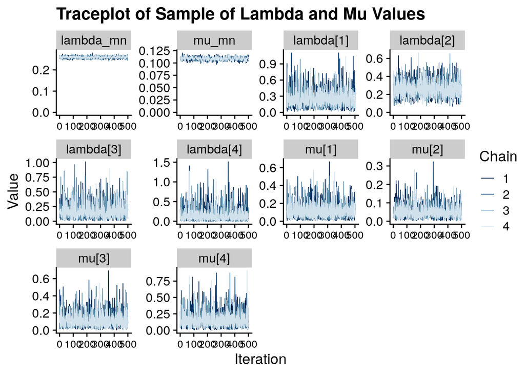

```r
parameter_subset <- c(
  "lambda_mn", "mu_mn",
  "lambda[1]", "lambda[2]", "lambda[3]", "lambda[4]",
  "mu[1]",     "mu[2]",     "mu[3]",     "mu[4]"
  )

pnbd_long_twohiermean_stanfit$draws(inc_warmup = FALSE) |>
  mcmc_trace(pars = parameter_subset) +
  expand_limits(y = 0) +
  labs(
    x = "Iteration",
    y = "Value",
    title = "Traceplot of Sample of Lambda and Mu Values"
    ) +
  theme(axis.text.x = element_text(size = 10))
```

We also check $N_{eff}$ as a quick diagnostic of the fit.

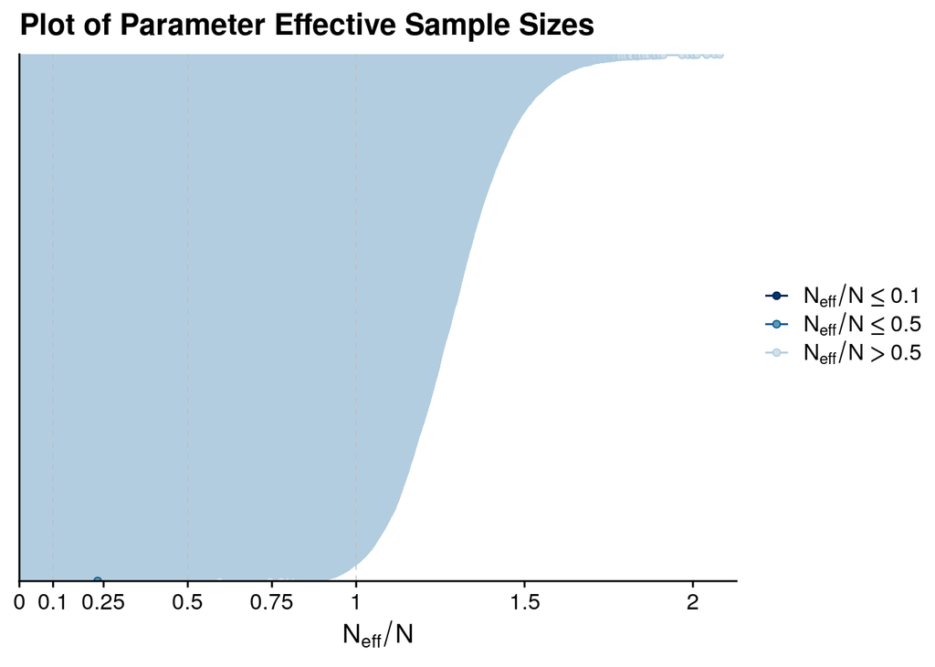

```r
pnbd_long_twohiermean_stanfit |>
  neff_ratio(pars = c("lambda_mn", "mu_mn", "lambda", "mu")) |>
  mcmc_neff() +
    ggtitle("Plot of Parameter Effective Sample Sizes")
```

Finally, we want to check out the energy diagnostic, which is often indicative of problems with the posterior mixing.

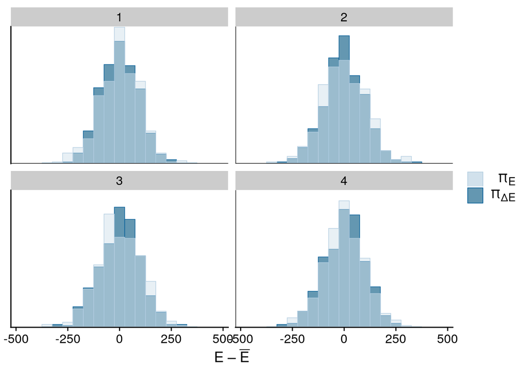

```r
pnbd_long_twohiermean_stanfit |>
  nuts_params() |>
  mcmc_nuts_energy(binwidth = 50)
```

## 2.3 Assess the Model

As we intend to run the same logic to assess each of our models, we have combined all this logic into a single function `run_model_assessment`, to run the simulations and combine the datasets.

```r
pnbd_stanfit <- pnbd_long_twohiermean_stanfit |>
  recover_types(customer_fit_stats_tbl)

pnbd_long_twohiermean_assess_data_lst <- run_model_assessment(
  model_stanfit    = pnbd_stanfit,
  insample_tbl     = customer_fit_subset_tbl,
  fit_label        = "pnbd_long_twohiermean",
  fit_end_dttm     = use_fit_end_date     |> as.POSIXct(),
  valid_start_dttm = use_valid_start_date |> as.POSIXct(),
  valid_end_dttm   = use_valid_end_date   |> as.POSIXct(),
  sim_seed         = 3210
  )

pnbd_long_twohiermean_assess_data_lst |> glimpse()
```

```
List of 5
 $ model_fit_index_filepath     : 'glue' chr "data/pnbd_long_twohiermean_assess_fit_index_tbl.rds"
 $ model_valid_index_filepath   : 'glue' chr "data/pnbd_long_twohiermean_assess_valid_index_tbl.rds"
 $ model_simstats_filepath      : 'glue' chr "data/pnbd_long_twohiermean_assess_model_simstats_tbl.rds"
 $ model_fit_simstats_filepath  : 'glue' chr "data/pnbd_long_twohiermean_assess_fit_simstats_tbl.rds"
 $ model_valid_simstats_filepath: 'glue' chr "data/pnbd_long_twohiermean_assess_valid_simstats_tbl.rds"
```

### 2.3.1 Check In-Sample Data Validation

We first check the model against the in-sample data.

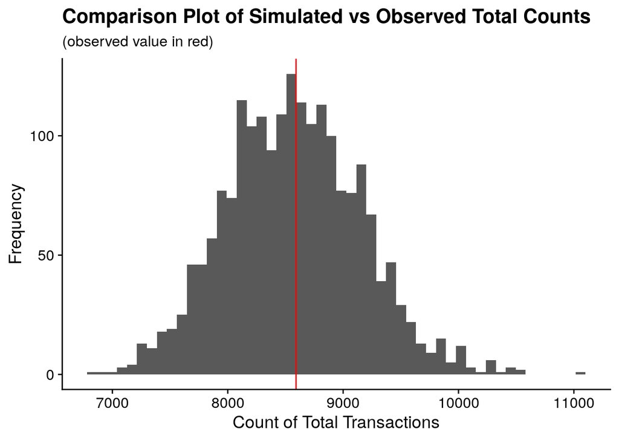

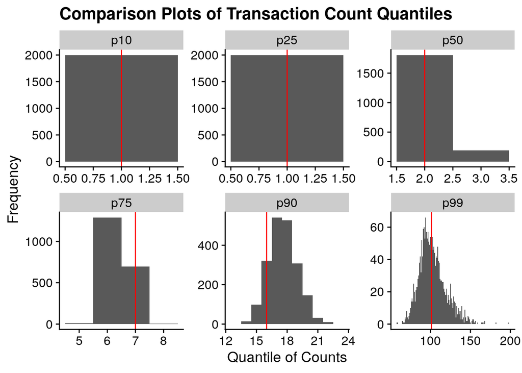

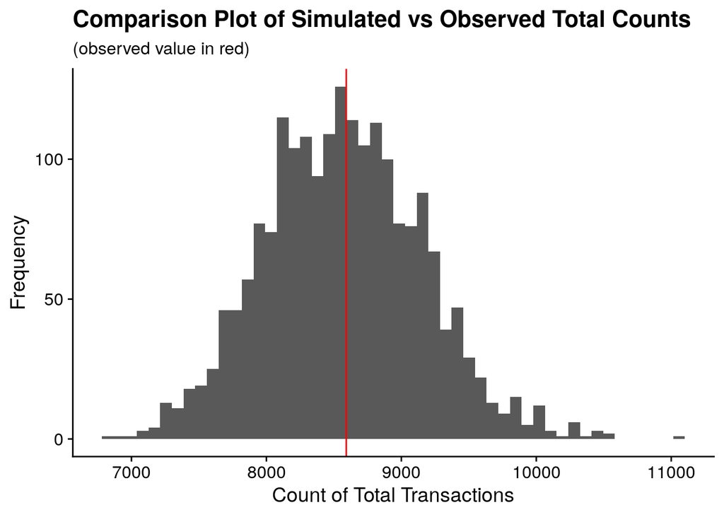

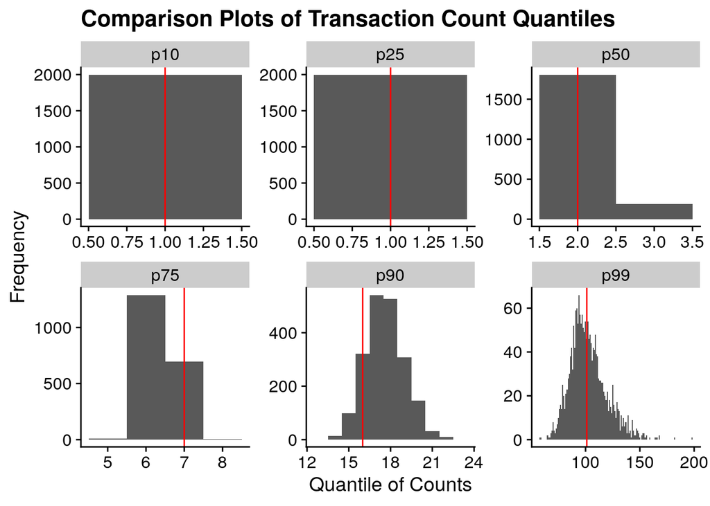

```r
simdata_tbl <- pnbd_long_twohiermean_assess_data_lst |>
  use_series(model_fit_index_filepath) |>
  read_rds() |>
  use_series(sim_file) |>
  map_dfr(read_rds) |>
  select(customer_id, draw_id, sim_data) |>
  unnest(sim_data) |>
  bind_rows(sim_init_tbl) |>
  arrange(customer_id, draw_id, tnx_timestamp)


assess_plots_lst <- create_model_assessment_plots(
  obsdata_tbl = customer_fit_transactions_tbl,
  simdata_tbl = simdata_tbl
  )

assess_plots_lst |> map(print)
```

This fit looks reasonable and appears to capture most of the aspects of the data used to fit it. Given that this is a synthetic dataset, this is not surprising, but at least we appreciate that our model is valid.

### 2.3.2 Check Out-of-Sample Data Validation

We now repeat for the out-of-sample data.

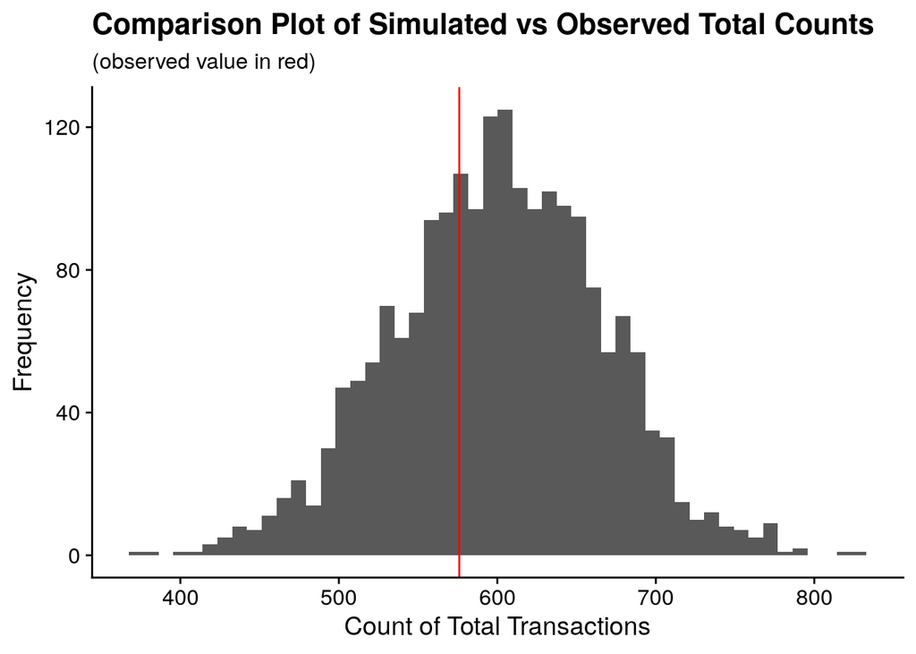

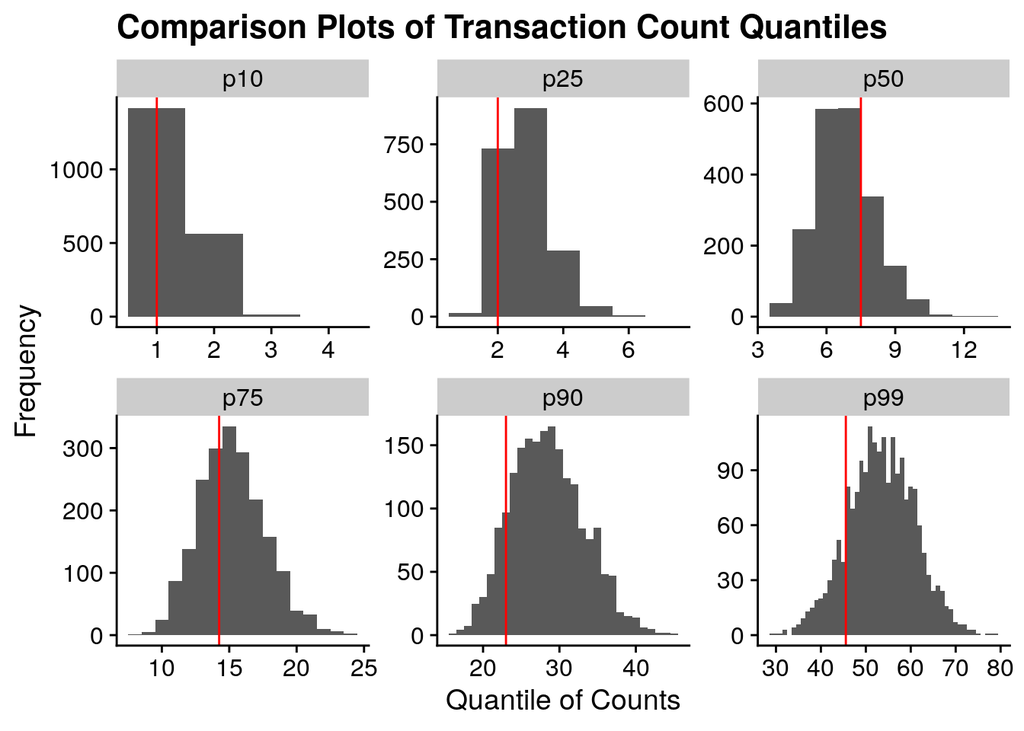

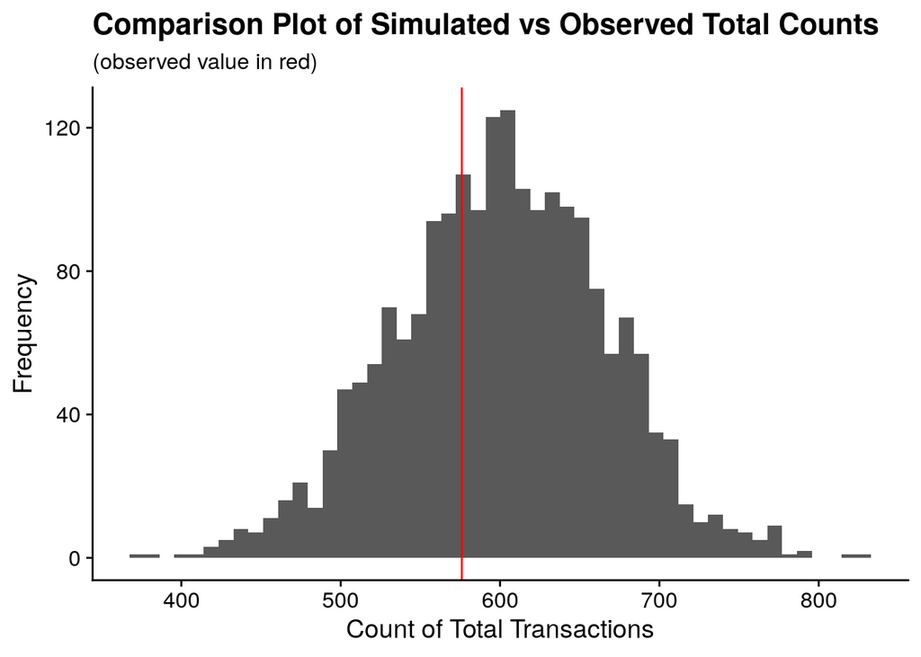

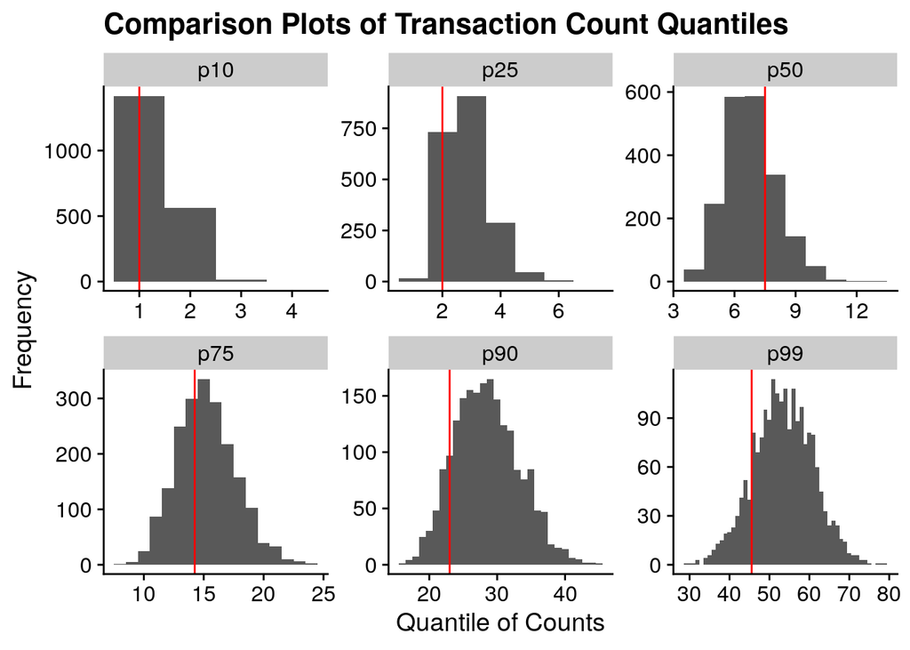

```r
simdata_tbl <- pnbd_long_twohiermean_assess_data_lst |>
  use_series(model_valid_index_filepath) |>
  read_rds() |>
  use_series(sim_file) |>
  map_dfr(read_rds) |>
  select(customer_id, draw_id, sim_data) |>
  unnest(sim_data) |>
  arrange(customer_id, draw_id, tnx_timestamp)


assess_plots_lst <- create_model_assessment_plots(
  obsdata_tbl = customer_valid_transactions_tbl,
  simdata_tbl = simdata_tbl
  )

assess_plots_lst |> map(print)
```

# 3 Fit Hierarchical Lambda Model

Our next model puts a hierarchical prior around both $\lambda$ parameters, `lambda_mn` and `lambda_cv`.

Once again we use a Gamma prior for both these parameters.

## 3.1 Compile and Fit Stan Model

We now compile this model using `CmdStanR`.

```r
pnbd_twohierlambda_stanmodel <- cmdstan_model(
  "stan_code/pnbd_twohier_lambda.stan",
  include_paths =   stan_codedir,
  pedantic      =           TRUE,
  dir           =  stan_modeldir
  )
```

We then use this compiled model with our data to produce a fit of the data.

```r
stan_modelname <- "pnbd_long_twohierlambda"
stanfit_prefix <- str_c("fit_", stan_modelname)
stanfit_seed   <- stanfit_seed + 1

stanfit_object_file <- glue("data/{stanfit_prefix}_stanfit.rds")


stan_data_lst <- customer_fit_stats_tbl |>
  select(customer_id, x, t_x, T_cal) |>
  compose_data(
    hier_lambda_mn_p1 = 0.25,
    hier_lambda_mn_p2 = 1.00,

    hier_lambda_cv_p1 = 1.00,
    hier_lambda_cv_p2 = 1.00,

    mu_mn             = 0.10,
    mu_cv             = 1.00
    )

if(!file_exists(stanfit_object_file)) {
  pnbd_long_twohierlambda_stanfit <- pnbd_twohierlambda_stanmodel$sample(
    data            =                stan_data_lst,
    chains          =                            4,
    iter_warmup     =                          500,
    iter_sampling   =                          500,
    seed            =                 stanfit_seed,
    save_warmup     =                         TRUE,
    output_dir      =                stan_modeldir,
    output_basename =               stanfit_prefix,
    )

  pnbd_long_twohierlambda_stanfit$save_object(stanfit_object_file, compress = "gzip")

} else {
  pnbd_long_twohierlambda_stanfit <- read_rds(stanfit_object_file)
}

pnbd_long_twohierlambda_stanfit$print()
```

```
  variable      mean    median    sd   mad        q5       q95 rhat ess_bulk
 lp__      -97695.16 -97691.70 97.82 95.41 -97858.90 -97536.77 1.02      223
 lambda_mn      0.26      0.26  0.01  0.01      0.25      0.27 1.00     1369
 lambda_cv      1.02      1.02  0.02  0.02      0.99      1.05 1.02      197
 lambda[1]      0.25      0.21  0.16  0.14      0.06      0.54 1.00     2118
 lambda[2]      0.26      0.25  0.09  0.09      0.13      0.42 1.00     2603
 lambda[3]      0.16      0.12  0.14  0.10      0.02      0.43 1.00     1495
 lambda[4]      0.14      0.08  0.17  0.10      0.00      0.49 1.00     1744
 lambda[5]      0.46      0.43  0.22  0.19      0.17      0.86 1.00     2525
 lambda[6]      0.13      0.12  0.07  0.07      0.04      0.28 1.00     2102
 lambda[7]      0.32      0.31  0.04  0.03      0.26      0.38 1.00     2202
 ess_tail
      508
     1415
      466
     1099
     1441
      864
      762
     1318
     1249
     1518

 # showing 10 of 13817 rows (change via 'max_rows' argument or 'cmdstanr_max_rows' option)
```

We have some basic HMC-based validity statistics we can check.

```r
pnbd_long_twohierlambda_stanfit$cmdstan_diagnose()
```

```
Processing csv files: /home/rstudio/btydwork/stan_models/fit_pnbd_long_twohierlambda-1.csvWarning: non-fatal error reading adaptation data
, /home/rstudio/btydwork/stan_models/fit_pnbd_long_twohierlambda-2.csvWarning: non-fatal error reading adaptation data
, /home/rstudio/btydwork/stan_models/fit_pnbd_long_twohierlambda-3.csvWarning: non-fatal error reading adaptation data
, /home/rstudio/btydwork/stan_models/fit_pnbd_long_twohierlambda-4.csvWarning: non-fatal error reading adaptation data


Checking sampler transitions treedepth.
Treedepth satisfactory for all transitions.

Checking sampler transitions for divergences.
No divergent transitions found.

Checking E-BFMI - sampler transitions HMC potential energy.
E-BFMI satisfactory.

Effective sample size satisfactory.

Split R-hat values satisfactory all parameters.

Processing complete, no problems detected.
```

## 3.2 Visual Diagnostics of the Sample Validity

Now that we have a sample from the posterior distribution we need to create a few different visualisations of the diagnostics.

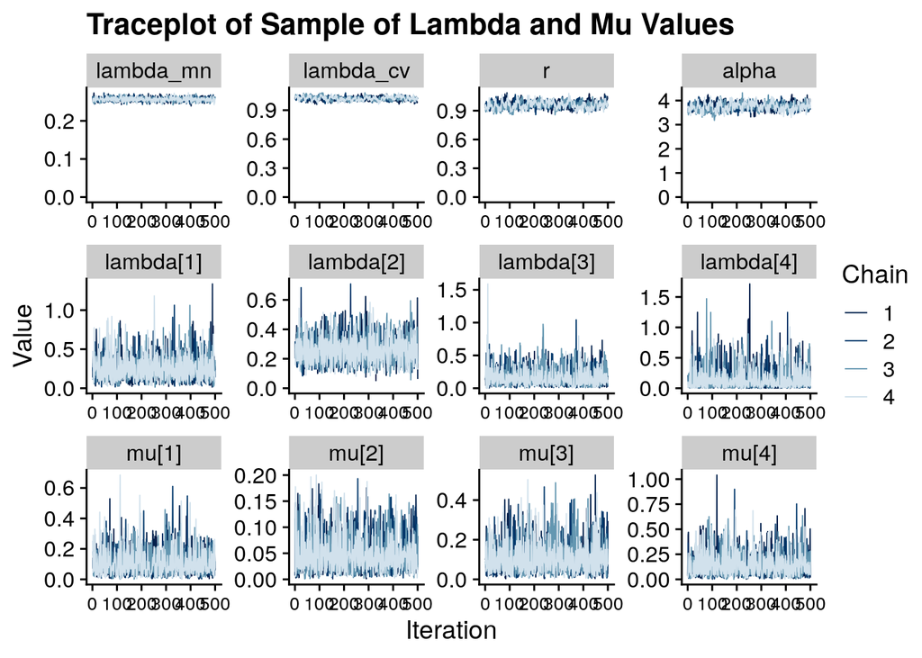

```r
parameter_subset <- c(
  "lambda_mn", "lambda_cv", "r", "alpha",
  "lambda[1]", "lambda[2]", "lambda[3]", "lambda[4]",
  "mu[1]",     "mu[2]",     "mu[3]",     "mu[4]"
  )

pnbd_long_twohierlambda_stanfit$draws(inc_warmup = FALSE) |>
  mcmc_trace(pars = parameter_subset) +
  expand_limits(y = 0) +
  labs(
    x = "Iteration",
    y = "Value",
    title = "Traceplot of Sample of Lambda and Mu Values"
    ) +
  theme(axis.text.x = element_text(size = 10))
```

We also check $N_{eff}$ as a quick diagnostic of the fit.

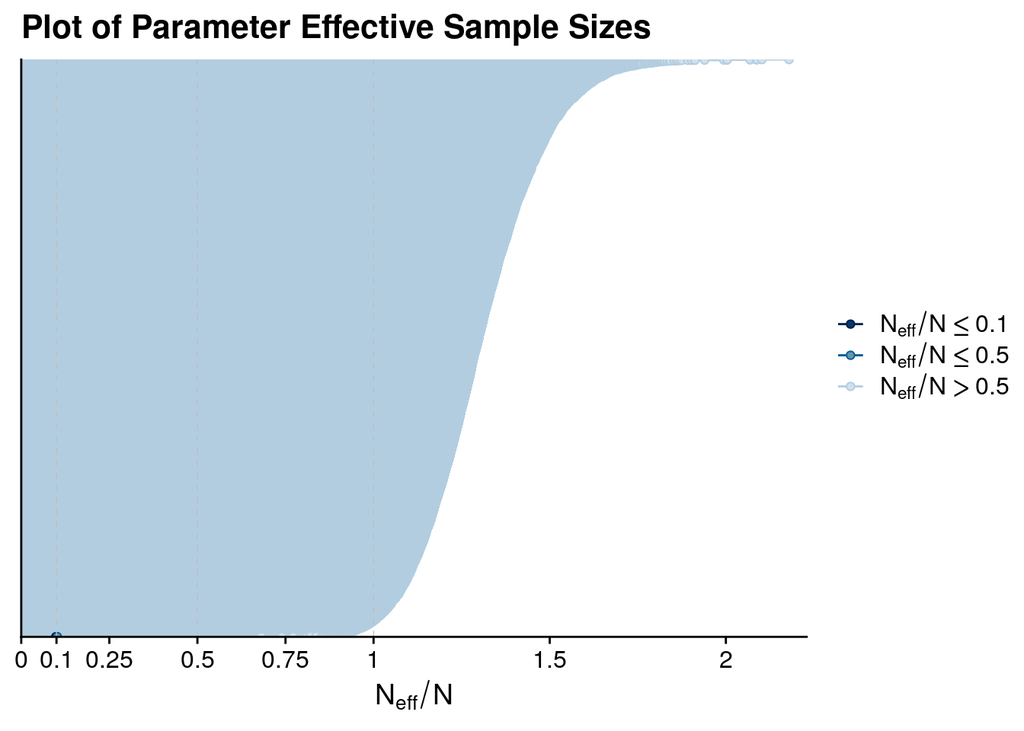

```r
pnbd_long_twohierlambda_stanfit |>
  neff_ratio(
    pars = c("lambda_mn", "lambda_cv", "r", "alpha", "lambda", "mu")
    ) |>
  mcmc_neff() +
    ggtitle("Plot of Parameter Effective Sample Sizes")
```

Finally, we want to check out the energy diagnostic, which is often indicative of problems with the posterior mixing.

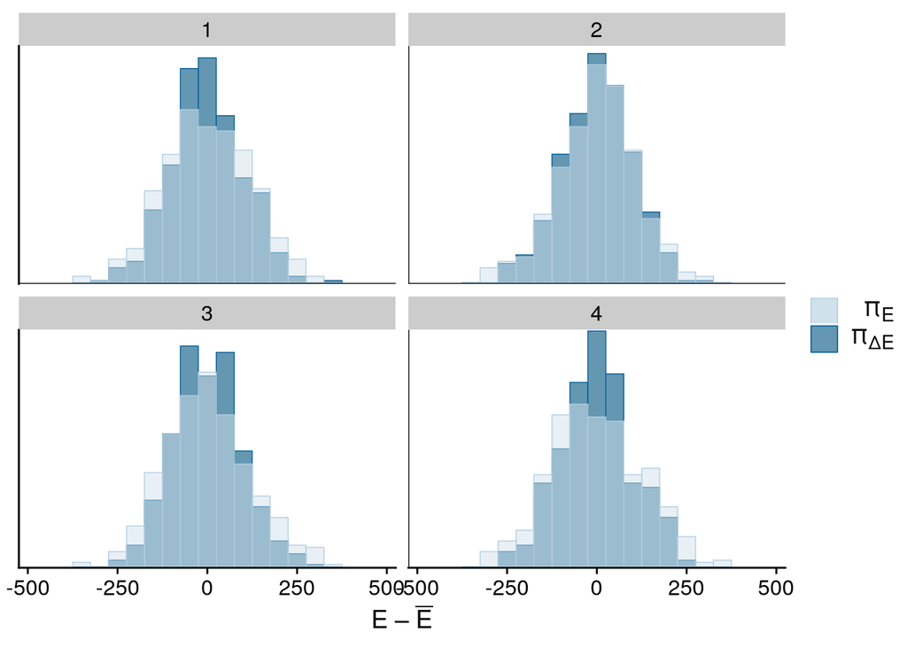

```r
pnbd_long_twohierlambda_stanfit |>
  nuts_params() |>
  mcmc_nuts_energy(binwidth = 50)
```

## 3.3 Assess the Model

As we intend to run the same logic to assess each of our models, we have combined all this logic into a single function `run_model_assessment`, to run the simulations and combine the datasets.

```r
pnbd_stanfit <- pnbd_long_twohierlambda_stanfit |>
  recover_types(customer_fit_stats_tbl)

pnbd_long_twohierlambda_assess_data_lst <- run_model_assessment(
  model_stanfit    = pnbd_stanfit,
  insample_tbl     = customer_fit_subset_tbl,
  fit_label        = "pnbd_long_twohierlambda",
  fit_end_dttm     = use_fit_end_date     |> as.POSIXct(),
  valid_start_dttm = use_valid_start_date |> as.POSIXct(),
  valid_end_dttm   = use_valid_end_date   |> as.POSIXct(),
  sim_seed         = 3220
  )

pnbd_long_twohierlambda_assess_data_lst |> glimpse()
```

```
List of 5
 $ model_fit_index_filepath     : 'glue' chr "data/pnbd_long_twohierlambda_assess_fit_index_tbl.rds"
 $ model_valid_index_filepath   : 'glue' chr "data/pnbd_long_twohierlambda_assess_valid_index_tbl.rds"
 $ model_simstats_filepath      : 'glue' chr "data/pnbd_long_twohierlambda_assess_model_simstats_tbl.rds"
 $ model_fit_simstats_filepath  : 'glue' chr "data/pnbd_long_twohierlambda_assess_fit_simstats_tbl.rds"
 $ model_valid_simstats_filepath: 'glue' chr "data/pnbd_long_twohierlambda_assess_valid_simstats_tbl.rds"
```

### 3.3.1 Check In-Sample Data Validation

We first check the model against the in-sample data.

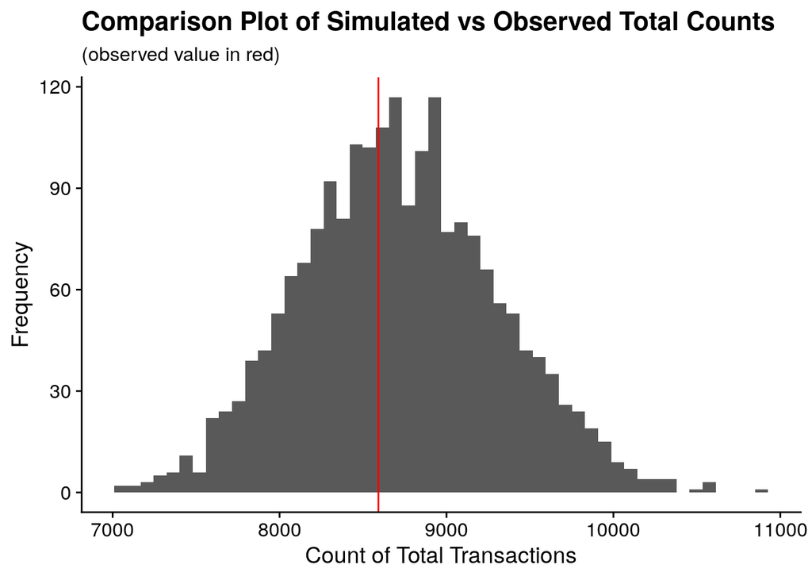

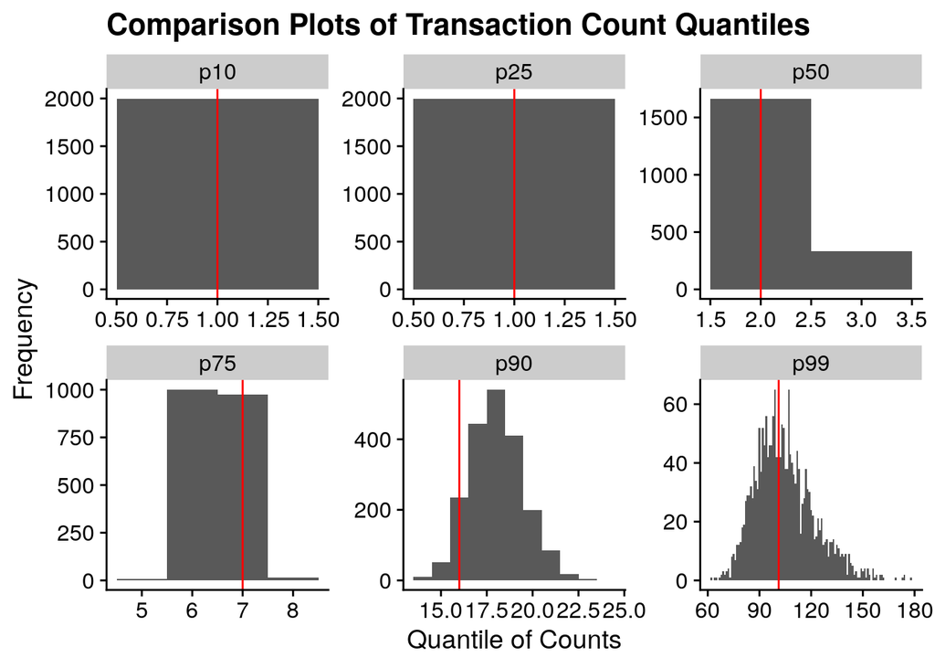

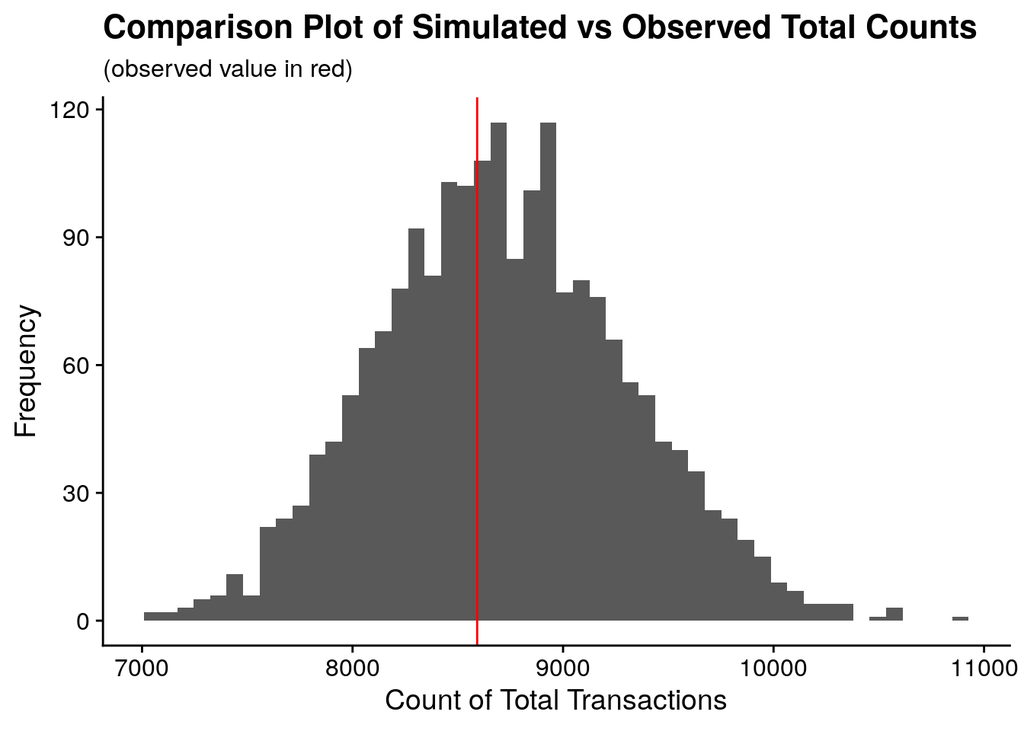

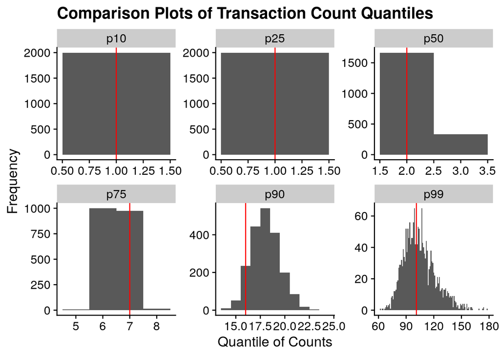

```r
simdata_tbl <- pnbd_long_twohierlambda_assess_data_lst |>
  use_series(model_fit_index_filepath) |>
  read_rds() |>
  use_series(sim_file) |>
  map_dfr(read_rds) |>
  select(customer_id, draw_id, sim_data) |>
  unnest(sim_data) |>
  bind_rows(sim_init_tbl) |>
  arrange(customer_id, draw_id, tnx_timestamp)


assess_plots_lst <- create_model_assessment_plots(
  obsdata_tbl = customer_fit_transactions_tbl,
  simdata_tbl = simdata_tbl
  )

assess_plots_lst |> map(print)
```

This fit looks reasonable and appears to capture most of the aspects of the data used to fit it. Given that this is a synthetic dataset, this is not surprising, but at least we appreciate that our model is valid.

### 3.3.2 Check Out-of-Sample Data Validation

We now repeat for the out-of-sample data.

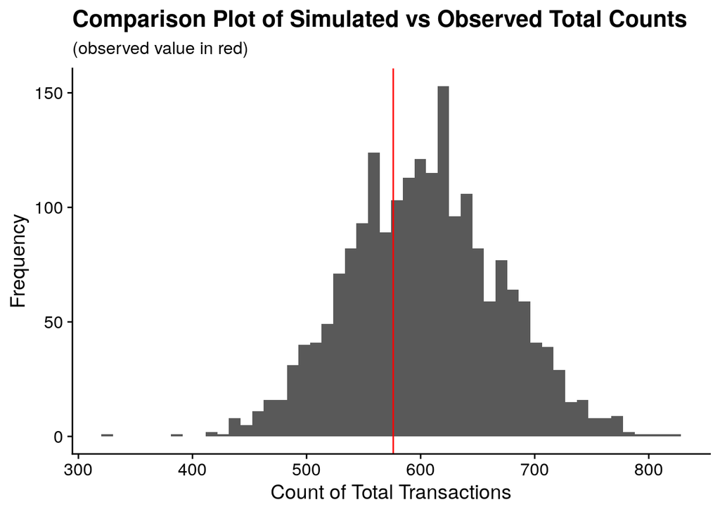

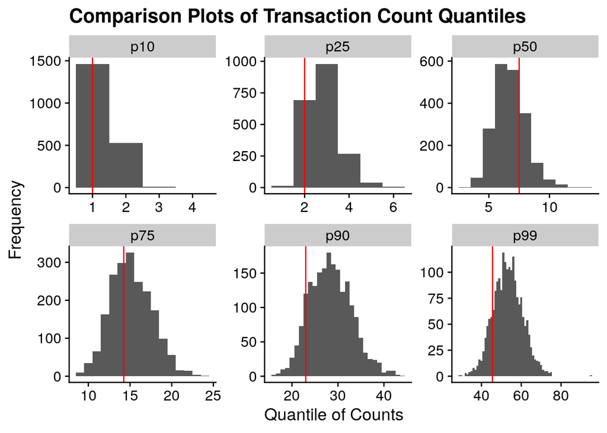

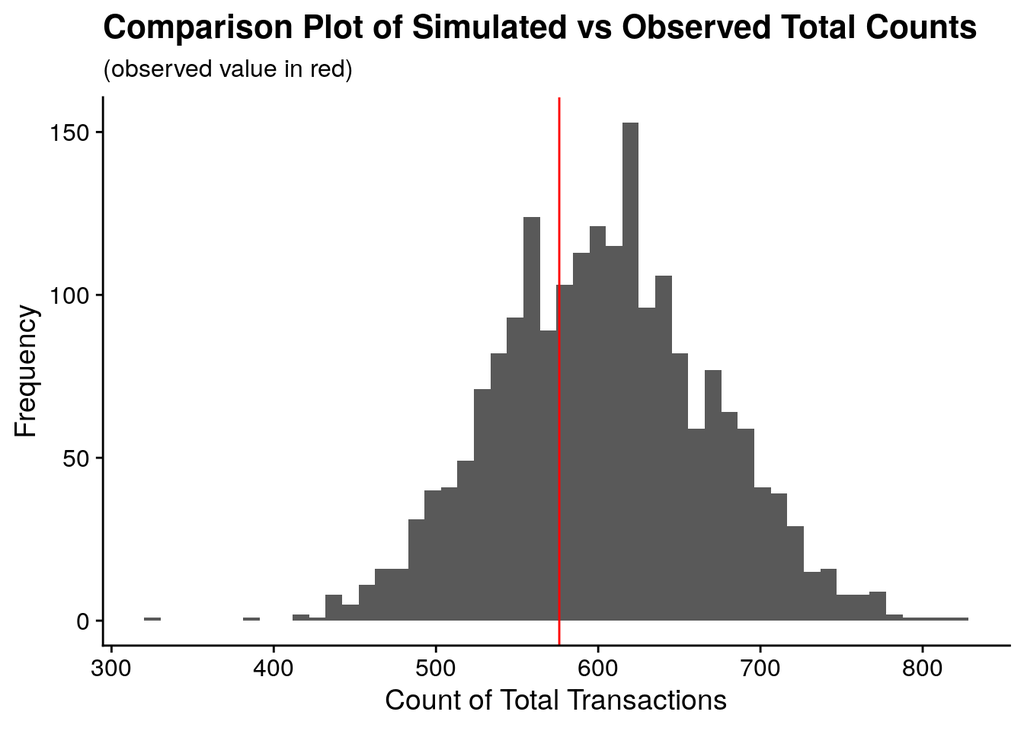

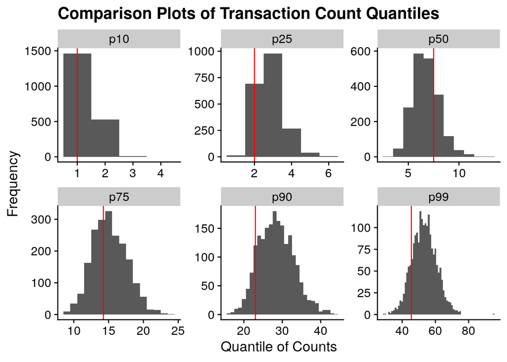

```r
simdata_tbl <- pnbd_long_twohierlambda_assess_data_lst |>
  use_series(model_valid_index_filepath) |>
  read_rds() |>
  use_series(sim_file) |>
  map_dfr(read_rds) |>
  select(customer_id, draw_id, sim_data) |>
  unnest(sim_data) |>
  arrange(customer_id, draw_id, tnx_timestamp)


assess_plots_lst <- create_model_assessment_plots(
  obsdata_tbl = customer_valid_transactions_tbl,
  simdata_tbl = simdata_tbl
  )

assess_plots_lst |> map(print)
```

As for our short time frame data, overall our model is working well.